# Lab 8: Practice Midterm Questions

Felix Su

March 11, 2016

*Source file* ⇒ /Users/felixsu/ucb_classes/Sp16/STAT133/labs/lab8/Lab-8-Su.Rmd

### 1. The following loop can be done as a vectorized calculation. What is the equivalent vectorized calculation?

```r
vec = 1:50
i = 1

while(i < 50) {
  vec[i] <- i^2
  i <- i + 1
}
```

#### Answer:

```r
vec = 1:50
i = 1
vec <- sapply(vec, function(i) i^2)
vec
```

```
##  [1]    1    4    9   16   25   36   49   64   81  100  121  144  169  196
## [15]  225  256  289  324  361  400  441  484  529  576  625  676  729  784
## [29]  841  900  961 1024 1089 1156 1225 1296 1369 1444 1521 1600 1681 1764
## [43] 1849 1936 2025 2116 2209 2304 2401 2500
```

### 2. Write down what the vector x will contain after each line of R code, if they are executed sequentially.

#### a. x = [0, 2, 4, 6, 8]

```r
x <- seq(from = 0, to = 8, by = 2) #creates a sequence of even numbers from 0 to 8 inclusive
```

#### b. x = [NA, NA, 4, 6, 8]

```r
x[x < 4] <- NA #replaces all elements of x that are < 4 with NA
```

#### c. x = [0, 0, 0, 0, 0]

```r
x[] <- 0 #replaces all elements of x with 0s
```

#### d. x = 0

```r
x <- 0 #replaces x with 0
```

### 3. Fill in the appropriate types of R objects in this sentence: The lapply function in R operates on *a vector or list* and returns *a list*. There may be more than one correct answer.

### 4. Suppose we have a 5000 by 3 matrix `m`

```r
set.seed(1337)
m <- matrix(runif(15000, -3, 3), ncol = 3)
```

#### a. We need to create a vector containing the sum of the squared entries in each row of `m`. Write R code to do this in two different ways:

#### * Using a for loop and saving the result in an object called `m.ssq.loop`:

```r
m.ssq.loop <- c()
row_sum <- 0
for(r in 1:nrow(m)) {
  for(c in 1:ncol(m)) {
    row_sum <- row_sum + m[r,c]^2
  }
  m.ssq.loop <- c(m.ssq.loop, row_sum)
  row_sum <- 0
}

head(m.ssq.loop) # First few elements
```

```
## [1] 10.219360  4.811994  9.842371  7.161204  6.058554 14.288626
```

#### * Using the `apply` function and saving the result in an object called m.ssq.apply (See ?apply):

```r
m.ssq.apply <- m %>%
  apply(1:2, function(x) x^2) %>%
  apply(1,sum)

head(m.ssq.apply) # First few elements
```

```
## [1] 10.219360  4.811994  9.842371  7.161204  6.058554 14.288626
```

#### b. Write a script that will check if your answers in part (a) are the same. It should return `TRUE` if the two vectors are exactly the same and `FALSE` otherwise. This is called a sanity check, and you should do them often when coding.

```r
check_same <- function(x,y) {
  return(isTRUE(all.equal(x,y)))
}

check_same(m.ssq.loop,m.ssq.apply)
```

```
## [1] TRUE
```

### 5. `table1` is given below:

```r
Year <- c(2000, 2001)
Algeria <- c(7 ,9)
Brazil <- c(12, NA)
Columbia <- c(16, 18)

table1 <- data.frame(Year, Algeria, Brazil, Columbia)
table1
```

| Year | Algeria | Brazil | Columbia |
| --- | --- | --- | --- |
| 2000 | 7 | 12 | 16 |
| 2001 | 9 | NA | 18 |

#### a. Wrangle `table1` into the object `table2` as shown below:

```r
table2 <- table1 %>%
  gather(key="Country", val="Value", Algeria, Brazil, Columbia)
table2
```

| Year | Country | Value |
| --- | --- | --- |
| 2000 | Algeria | 7 |
| 2001 | Algeria | 9 |
| 2000 | Brazil | 12 |
| 2001 | Brazil | NA |
| 2000 | Columbia | 16 |
| 2001 | Columbia | 18 |

#### b. Use `table2` to produce `table3` as printed below:

```r
grouped <- table2 %>% group_by(Year) %>% summarise(Average = mean(Value, na.rm=TRUE))
table3 <- table2 %>%
    spread(key="Country", val="Value") %>%
    transform(Average = grouped$Average)
# ------------------------OR-------------------------
# wide <- table2 %>%
#   wide(key="Country", val="Value")
# table3 <- spread %>%
#   transform(Average = rowMeans(wide[,-1], na.rm = TRUE))
table3
```

| Year | Algeria | Brazil | Columbia | Average |
| --- | --- | --- | --- | --- |
| 2000 | 7 | 12 | 16 | 11.66667 |
| 2001 | 9 | NA | 18 | 13.50000 |

### 6. Consider the following graphic:

#### a. What are the glyphs in this graph?

```
    Answer: The glyphs are dots representing people in the CPS85 table
```

#### b. What are the aesthetics of each glyph?

```
    Answer: x-pos, y-pos, color
```

#### c. Which variables are being mapped to each aesthetic?

```
    Answer: x-pos: years of education, y-pos: wage ($/hr), color: sex
```

#### d. Are the variables qualitative or quantitative?

```
    Answer: yrs of education: quantitative, wage: quantitative, sex: qualitative
```

#### e. What are the guides on this graph?

```
    Answer: x-axis: yrs of education, y-axis: hourly wage, color-legend: sex
```

#### f. Reconstruct this graphic using ggplot and the CPS85 data table. (Hint: the font size of the plot title is 20)

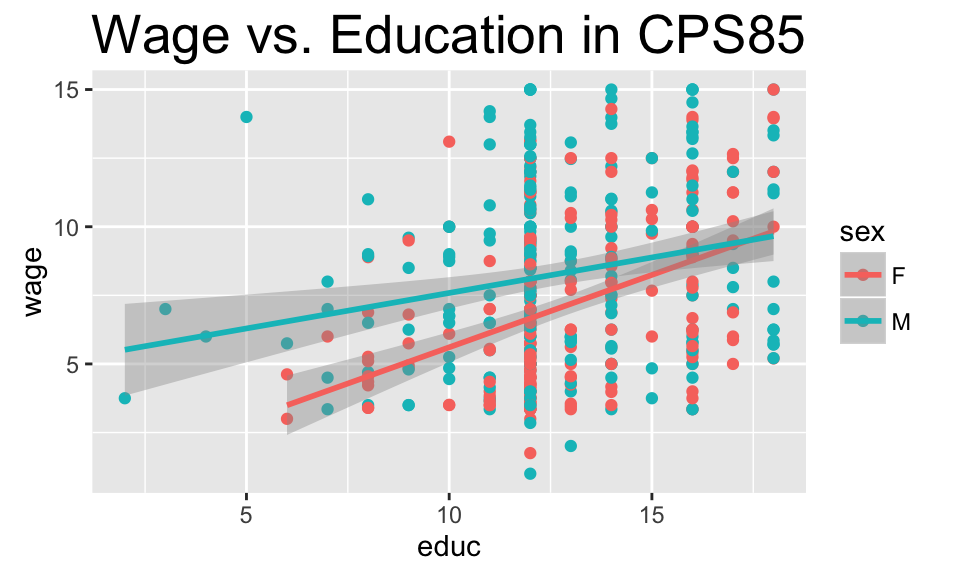

```r
CPS85 %>%
  subset(wage <= 15) %>%
ggplot(aes(x=educ,y=wage,col=sex)) +
  geom_point() +
  geom_smooth(method = "lm") +
  scale_y_continuous(breaks=seq(0, 15, 5)) +
  labs(title = "Wage vs. Education in CPS85") +
  theme(plot.title = element_text(size = 20))
```

### 7. Consider the string my.string given below:

```r
my.string <- "ggplot2 is a data visualization package for the statistical programming language R"
```

#### a. Write a function `SplitChars` that takes a character string as input and splits it into a vector of single character elements. Hint: the function `strsplit()` may be useful. The result of calling the function on my.string is shown.

```r
SplitChars <- function(str) {
  return(unlist(strsplit(str, "")))
}
my.string <- SplitChars(my.string)
my.string
```

```
##  [1] "g" "g" "p" "l" "o" "t" "2" " " "i" "s" " " "a" " " "d" "a" "t" "a"
## [18] " " "v" "i" "s" "u" "a" "l" "i" "z" "a" "t" "i" "o" "n" " " "p" "a"
## [35] "c" "k" "a" "g" "e" " " "f" "o" "r" " " "t" "h" "e" " " "s" "t" "a"
## [52] "t" "i" "s" "t" "i" "c" "a" "l" " " "p" "r" "o" "g" "r" "a" "m" "m"
## [69] "i" "n" "g" " " "l" "a" "n" "g" "u" "a" "g" "e" " " "R"
```

#### b. Write a for loop that counts the number of times that a, s, R, r appears in `my.string` and saves it in an object called `count`.

```r
count <- 0
for(i in 1:length(my.string)) {
  char <- my.string[i]
  if(char == "a" || char == "s" || char == "R" || char == "r") count <- count + 1
}
count
```

```
## [1] 20
```

#### c. Write a function Reverse that reverses the order of a vector of single characters. The result of using it on SplitChars(my.string) is shown below.

```r
my.string <- "ggplot2 is a data visualization package for the statistical programming language R"
Reverse <- function(vec) {
  return(vec[length(vec):1])
}
my.string %>% SplitChars %>% Reverse
```

```
##  [1] "R" " " "e" "g" "a" "u" "g" "n" "a" "l" " " "g" "n" "i" "m" "m" "a"
## [18] "r" "g" "o" "r" "p" " " "l" "a" "c" "i" "t" "s" "i" "t" "a" "t" "s"
## [35] " " "e" "h" "t" " " "r" "o" "f" " " "e" "g" "a" "k" "c" "a" "p" " "
## [52] "n" "o" "i" "t" "a" "z" "i" "l" "a" "u" "s" "i" "v" " " "a" "t" "a"
## [69] "d" " " "a" " " "s" "i" " " "2" "t" "o" "l" "p" "g" "g"
```